# Assignment2

Alejandro Pachón, Santiago Meza, Alexander Morgan

2023-04-21

## GitHub

Puedes visitar nuestro repositorio en internet, para más información : [**Nuestro Repositorio**](https://github.com/Alejandro29-tech/Assignment2)

## 1.1 Data acquisition

## Sensor ultrasonido HC-SR04

El sensor de ultrasonido HC-SR04 es un sensor popular utilizado para medir distancias. en caunto asu funcionamiento, El HC-SR04 emite una serie de pulsos de ultrasonido y mide el tiempo que tarda en recibir el eco de estos pulsos. Utiliza esta información para calcular la distancia desde el sensor hasta el objeto.El rango de medición del HC-SR04 es de 2 cm a 4 metros. en cuanto a su precicion es +/- de aproximadamente 3 mm. su angulo de apertura es de 15° respecto al centro del emisor y trabaja bajo una frecuencia de 40KHz, tambien utiliza como interfaaz de comunicacion el sistema de PWM para enviar o recibir señales. para mas infomacion se puede consultar el [**Datasheet**](http://www.datasheetcafe.com/hc-sr04-pdf-22772/)

[figure not shown]

## Sensor infrarrojo Sharp 2Y0A21

El Sharp 2Y0A21 emite un haz de luz infrarroja y mide la cantidad de luz reflejada por un objeto para calcular la distancia mediante un procesador integrado encargado de realizar el cálculo, El rango de medición es de 10 cm a 80 cm. su precision es de +/- aproximadamente 1 cm. funciona con una frecuancia de 38KHz y su angulo de deteccion es de 25°, en el aspecto de comunicacion no cuenta con una propia simplemente devuelve una tensión analógica proporcional a la distancia medida. para mas infomacion se puede consultar el [**Datasheet**](https://global.sharp/products/device/lineup/data/pdf/datasheet/gp2y0a21yk_e.pdf)

[figure not shown]

## 2.1 Data acquisition

the following sensors are used to perform this data acquisition and data projection project.

```r
library(dplyr)
library(tidyverse)
library(readxl)
library(knitr)
library(kableExtra)
# Leer el archivo Excel
datos <- read_excel("~/UNIVERSIDAD/8vo Semestre/Area electronica (electiva)/Assignment2/R/1.1.xlsx")
tabla_adq<-kable(datos)
tabla_adq <- tabla_adq %>%
  kable_styling(full_width = FALSE)
tabla_adq
```

| Sensor1 | Sensor1_cm | cm | Sensor2 | Sensor2_cm |
| --- | --- | --- | --- | --- |
| 1994 | 20 | 21.25 | 21.25 | 514 |
| 1201 | 20 | 21.30 | 21.30 | 513 |
| 1264 | 21 | 21.64 | 21.64 | 506 |
| 1388 | 23 | 23.44 | 23.44 | 472 |
| 1477 | 25 | 24.70 | 24.70 | 451 |
| 1605 | 27 | 26.09 | 26.09 | 430 |
| 1740 | 29 | 27.95 | 27.95 | 405 |
| 1838 | 31 | 29.11 | 29.11 | 391 |
| 1897 | 32 | 30.26 | 30.26 | 378 |
| 1953 | 33 | 31.50 | 31.50 | 365 |
| 2020 | 34 | 33.28 | 33.28 | 348 |
| 2110 | 36 | 34.89 | 34.89 | 334 |
| 2158 | 37 | 35.87 | 35.87 | 326 |
| 2254 | 38 | 37.32 | 37.32 | 315 |
| 2307 | 39 | 38.88 | 38.88 | 304 |
| 2376 | 40 | 40.56 | 40.56 | 293 |
| 2460 | 42 | 42.73 | 42.73 | 280 |
| 2550 | 43 | 43.99 | 43.99 | 273 |
| 2588 | 44 | 44.94 | 44.94 | 268 |
| 2642 | 45 | 46.33 | 46.33 | 261 |
| 2745 | 47 | 47.58 | 47.58 | 255 |
| 2775 | 47 | 48.90 | 48.90 | 249 |
| 2861 | 49 | 50.06 | 50.06 | 244 |
| 2930 | 50 | 52.27 | 52.27 | 235 |
| 2992 | 51 | 53.58 | 53.58 | 230 |
| 3080 | 52 | 55.52 | 55.52 | 223 |
| 3130 | 53 | 55.23 | 55.23 | 224 |
| 3184 | 54 | 57.59 | 57.59 | 216 |
| 3256 | 55 | 59.49 | 59.49 | 210 |
| 3323 | 57 | 62.21 | 62.21 | 202 |
| 3339 | 57 | 62.21 | 62.21 | 202 |
| 3401 | 58 | 63.65 | 63.65 | 198 |
| 3430 | 58 | 63.65 | 63.65 | 198 |
| 3470 | 58 | 71.03 | 71.03 | 180 |
| 3558 | 59 | 67.98 | 67.98 | 187 |
| 3596 | 61 | 67.98 | 67.98 | 187 |
| 3610 | 62 | 69.25 | 69.25 | 184 |
| 3672 | 63 | 72.89 | 72.89 | 176 |
| 3749 | 64 | 71.03 | 71.03 | 180 |
| 3786 | 65 | 72.89 | 72.89 | 176 |
| 3860 | 66 | 73.85 | 73.85 | 174 |
| 3864 | 66 | 75.34 | 75.34 | 171 |
| 3873 | 66 | 74.34 | 74.34 | 173 |
| 3875 | 66 | 76.89 | 76.89 | 168 |
| 3954 | 67 | 76.37 | 76.37 | 169 |
| 3948 | 67 | 76.89 | 76.89 | 168 |
| 3951 | 68 | 79.05 | 79.05 | 164 |
| 4004 | 68 | 77.96 | 77.96 | 164 |
| 4029 | 69 | 79.96 | 79.96 | 166 |
| 4083 | 70 | 79.05 | 79.05 | 168 |
| 4092 | 70 | 79.05 | 79.05 | 160 |
| 4159 | 71 | 81.33 | 81.33 | 163 |

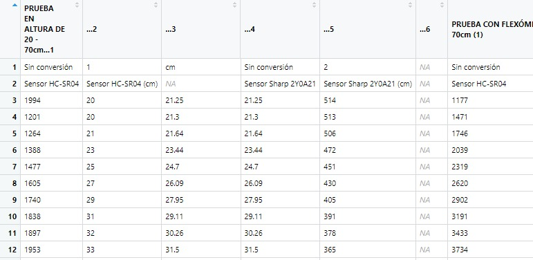

## Modelo lineal para HC-SR04 (Sensor1)

El sensor de ultrasonido HC-SR04 es una herramienta utilizada para medir distancias en proyectos electrónicos. Sin embargo, es necesario crear un modelo matemático que permita predecir las mediciones del sensor con mayor precisión y eficacia. Una forma de lograr esto es mediante la creación de un modelo lineal que relacione las mediciones del sensor con las variables que afectan su desempeño. como se ve acontinuacion:

```r
# Modelo lineal para Sensor1
datos <- read_excel("~/UNIVERSIDAD/8vo Semestre/Area electronica (electiva)/Assignment2/R/1.1.xlsx")
model_lin_Sensor_1 <- lm(Sensor1 ~ Sensor1_cm, data = datos)

# Modelo lineal regularizado para Sensor1
library(glmnet)
X<-as.matrix(datos[,c("Sensor1_cm","cm")])
y<-as.matrix(datos[,c("Sensor1")])
model_reg_Sensor_1 <- glmnet(X, y, alpha = 1)

# Modelo lineal para Sensor2
model_lin_Sensor2 <- lm(Sensor2 ~ Sensor2_cm, data = datos)

# Modelo lineal regularizado para Sensor2
model_reg_Sensor2 <- glmnet(as.matrix(datos[,c("Sensor2_cm","cm")]), as.matrix(datos[,c("Sensor2")]), alpha = 1)
```

## 2.1 Cargar datos

```r
knitr::opts_chunk$set(echo = TRUE)
library(tidyverse)
library(glmnet)
library(kableExtra)

# Cambiar nombres de columnas
colnames(datos) <- c("Sensor1", "Sensor1_cm", "cm", "Sensor2", "Sensor2_cm")

# Visualizar tabla
kable(datos[1:10,], caption = "Primeros 10 datos del dataset") %>% kable_classic("striped")
```

Primeros 10 datos del dataset

| Sensor1 | Sensor1_cm | cm | Sensor2 | Sensor2_cm |
| --- | --- | --- | --- | --- |
| 1994 | 20 | 21.25 | 21.25 | 514 |
| 1201 | 20 | 21.30 | 21.30 | 513 |
| 1264 | 21 | 21.64 | 21.64 | 506 |
| 1388 | 23 | 23.44 | 23.44 | 472 |
| 1477 | 25 | 24.70 | 24.70 | 451 |
| 1605 | 27 | 26.09 | 26.09 | 430 |
| 1740 | 29 | 27.95 | 27.95 | 405 |
| 1838 | 31 | 29.11 | 29.11 | 391 |
| 1897 | 32 | 30.26 | 30.26 | 378 |
| 1953 | 33 | 31.50 | 31.50 | 365 |

## Renombrar las columnas

```r
colnames(datos) <- c("Sensor1", "Sensor1_cm", "cm", "Sensor2", "Sensor2_cm")
```

## KNN para el Sensor 1

Para el entrenamiento mediante el metodo e KNN para el sensor HC-SR04, veremos cómo utilizar los datos de entrenamiento para determinar los k vecinos más cercanos a una instancia desconocida y cómo clasificar o predecir el valor de distancia basado en la mayoría de los valores de los vecinos más cercanos.

```r
library(caret)
modelo_sensor1 <- train(Sensor1_cm ~ cm, data = datos, method = "knn")
```

## Hacer una predicción para un nuevo valor de sensor 1

```r
nuevo_valor_sensor1 <- 20 # Por ejemplo
prediccion_sensor1 <- predict(modelo_sensor1, newdata = data.frame(cm = nuevo_valor_sensor1))
```

# Imprimir la predicción para el Sensor 1

```r
print(prediccion_sensor1)
```

```
## [1] 21.8
```

## Entrenar el modelo KNN para el Sensor 2

```r
modelo_sensor2 <- train(Sensor2_cm ~ cm, data = datos, method = "knn")
```

## Hacer una predicción para un nuevo valor de sensor 2

```r
nuevo_valor_sensor2 <- 30 # Por ejemplo
prediccion_sensor2 <- predict(modelo_sensor2, newdata = data.frame(cm = nuevo_valor_sensor2))
```

# Imprimir la predicción para el Sensor 2

```r
print(prediccion_sensor2)
```

```
## [1] 377.4
```